# Suni’s Weekly FDA Analysis Check-in Progress – Pupil Light Reflex

SG

2022-08-18

## To Do:

1. Mean plot by user category
2. Within subject difference plots
- Mean
- SD
3. fPCA
- Plot first several PCs
- Plot score by group & time point
- Start with fPCA for all data,
  - possible to run separately for pre and post or the run on pre and predict on post
- refund.shiny for quick visualization (plot_shiny)
4. fPCA on within-subject difference data
5. Function on Scalar Regresstion (use class notes)
- Model: $Y_{ij}(t) = f_0(t) + f_1(t)I(user = Occassional) +f_2(t)I(user == Daily) + b_{ij}(t) + e_{ij}(t)$
- $b_{ij}(t)$ is a random effect (RE) for subject, start modeling with independence assumption between pt-time points and then incorporate RE later

## Task Worked On From Last Week:

1. Plotting data
2. Identifying Mis-Aligned Trajectories

### Notes

1. Send HTML of Rmarkdown to JW & AL by Tuesday night
2. Ask quick questions through email (e.g. components of objects or error messages)

## Background

Pupil size light reflex to a light test is a potential test to determine a person is under the influence of THC and be able to be use as a field sobriety measures. The goals of the analysis to:

### Potential Topics

1. Determine the variability of pupil light reflex in a sober population
2. Determine the effectiveness of pupil light reflex to measure sobriety after smoking THC Question - dose response?
3. Jointly model pupil light reflex and blink rate during a light test (another data set)

Pupil size light reflex to light does not habituated to THC use (smoking).

*Currently this field does not use FDA, so any FDA in topic area may be publishable*

### Questions:

1. Can we translate frame into time? Do we need to? – No need to translate to time dimension, also time drift shouldn’t be an issue because duration of test is short

### Questions for Ben:

1. What do the NA values in frame? (pupil size and percent change variables have no missing values)
- Look at values around NA frame and see what the size of the difference in pupil size and percent change is
2. One participant in “post” had negative values for pupil size. (Subject id:  
   001-030)

## Data summary

Data on pupil size during light reflex test. Pupil size was extracted at the image level based on image analysis techniques. Each test was performed simultaneously on right and left eye before and after THC use (smoking).

- USE percent change for analysis
- Start at frame 0
- End of test is not strictly defined (with FoS we shouldn’t need to define the end of the test)

```r
ps <- read.csv(file.path(ps_folder, "pupil_data_with_demo.csv"))

ps$demo_gender <- factor(ps$demo_gender,
                         levels = c(1,2),
                         labels = c("Male", "Female"))

ps$user_cat <- NA
ps$user_cat[ps$user_type == "non-user"] <- 0
ps$user_cat[ps$user_type == "occasional"] <- 1
ps$user_cat[ps$user_type == "daily"] <- 2

ps$user_cat <- factor(ps$user_cat,
                      levels = c(0,1,2),
                      labels = c("non-user",
                                 "occasional",
                                 "daily"))

ps$tp <- NA
ps$tp[ps$time == "pre2"] <- 0
ps$tp[ps$time == "post"] <- 1

ps$tp <- factor(ps$tp,
                levels = c(0,1),
                labels = c("pre2", "post"))

str(ps)
```

```
## 'data.frame':    204764 obs. of  14 variables:
##  $ subject_id    : chr  "001-002" "001-002" "001-002" "001-002" ...
##  $ time          : chr  "post" "post" "post" "post" ...
##  $ user_type     : chr  "daily" "daily" "daily" "daily" ...
##  $ eye           : chr  "Left" "Left" "Left" "Left" ...
##  $ percent_change: num  -1.92 -1.92 -1.92 -1.92 -1.92 ...
##  $ frame         : int  -222 -221 -220 -219 -218 -217 -216 -215 -214 -213 ...
##  $ pupil_size    : num  95.7 95.7 95.7 95.7 95.7 ...
##  $ demo_age      : num  34.9 34.9 34.9 34.9 34.9 ...
##  $ demo_weight   : int  250 250 250 250 250 250 250 250 250 250 ...
##  $ demo_height   : int  71 71 71 71 71 71 71 71 71 71 ...
##  $ demo_gender   : Factor w/ 2 levels "Male","Female": 1 1 1 1 1 1 1 1 1 1 ...
##  $ thc           : num  147 147 147 147 147 ...
##  $ user_cat      : Factor w/ 3 levels "non-user","occasional",..: 3 3 3 3 3 3 3 3 3 3 ...
##  $ tp            : Factor w/ 2 levels "pre2","post": 2 2 2 2 2 2 2 2 2 2 ...
```

```r
# total number of subjects
length(unique(ps$subject_id))
```

```
## [1] 101
```

```r
# subject level data
pt.df <- unique(ps[, c("subject_id", "tp", "user_cat", "demo_age",
                "demo_weight", "demo_height", "demo_gender", "thc")])

# Demographics Table by User Category
table1(~ demo_age + demo_weight + demo_height + demo_gender|user_cat,
       data = pt.df[pt.df$tp == "pre2", ])
```

|  | non-user (N=32) | occasional (N=36) | daily (N=31) | Overall (N=99) |
| --- | --- | --- | --- | --- |
| demo_age |  |  |  |  |
| Mean (SD) | 32.9 (4.90) | 31.6 (4.98) | 33.1 (5.60) | 32.5 (5.15) |
| Median [Min, Max] | 33.5 [25.7, 42.2] | 30.1 [25.1, 41.9] | 32.3 [25.4, 45.3] | 32.0 [25.1, 45.3] |
| demo_weight |  |  |  |  |
| Mean (SD) | 171 (48.5) | 173 (33.4) | 174 (32.7) | 173 (38.4) |
| Median [Min, Max] | 165 [85.0, 284] | 170 [105, 240] | 170 [113, 250] | 170 [85.0, 284] |
| demo_height |  |  |  |  |
| Mean (SD) | 68.0 (4.83) | 69.6 (3.60) | 68.0 (3.54) | 68.6 (4.06) |
| Median [Min, Max] | 67.0 [60.0, 78.0] | 69.5 [61.0, 76.0] | 69.0 [59.0, 76.0] | 69.0 [59.0, 78.0] |
| demo_gender |  |  |  |  |
| Male | 13 (40.6%) | 23 (63.9%) | 17 (54.8%) | 53 (53.5%) |
| Female | 19 (59.4%) | 13 (36.1%) | 14 (45.2%) | 46 (46.5%) |

```r
# number of subjects by timepoint (pre/post)
table(pt.df$tp)
```

```
##
## pre2 post
##   99   95
```

There are more subjects in total than the by time point. Indicating incomplete data with some subjects missing “pre” and others missing “post” measurement.

Plot of Pupil Size and Percent Change for “PRE” data by Eye and User Category

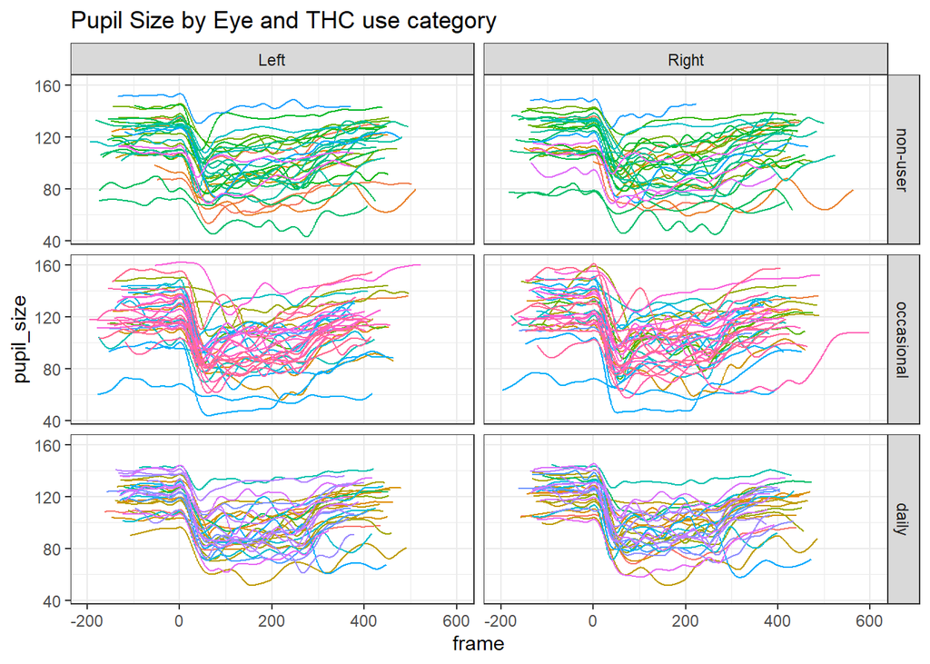

```r
pre.df <- ps[ps$tp == "pre2", ]

ggplot(pre.df, aes(x=frame, y = pupil_size, group = subject_id, color = subject_id))+
  geom_line(show.legend = FALSE)+
  facet_grid(rows = vars(user_cat), cols = vars(eye))+
  labs(title ="Pupil Size by Eye and THC use category")+
  theme_bw()
```

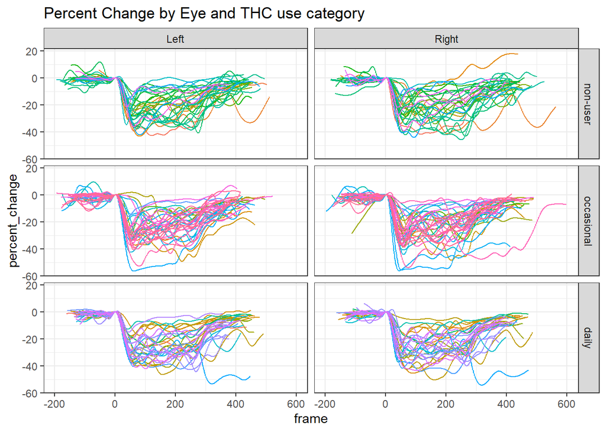

```r
ggplot(pre.df, aes(x=frame, y = percent_change, group = subject_id, color = subject_id))+
  geom_line(show.legend = FALSE)+
  facet_grid(rows = vars(user_cat), cols = vars(eye))+
  labs(title = "Percent Change by Eye and THC use category")+
  theme_bw()
```

Plot of PRE/POST for Right Eye

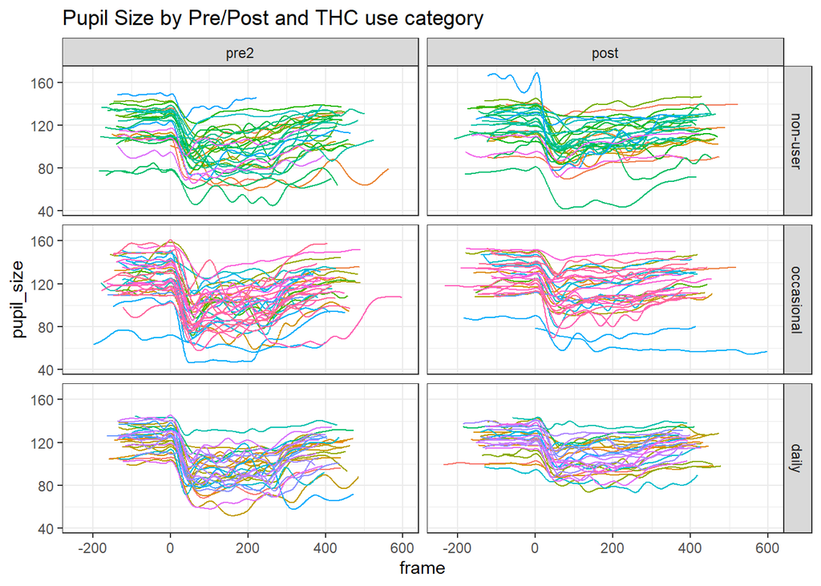

```r
right.df <- ps[ps$eye == "Right", ]

ggplot(right.df, aes(x=frame, y = pupil_size, group = subject_id, color = subject_id))+
  geom_line(show.legend = FALSE)+
  facet_grid(rows = vars(user_cat), cols = vars(tp))+
  labs(title ="Pupil Size by Pre/Post and THC use category")+
  theme_bw()
```

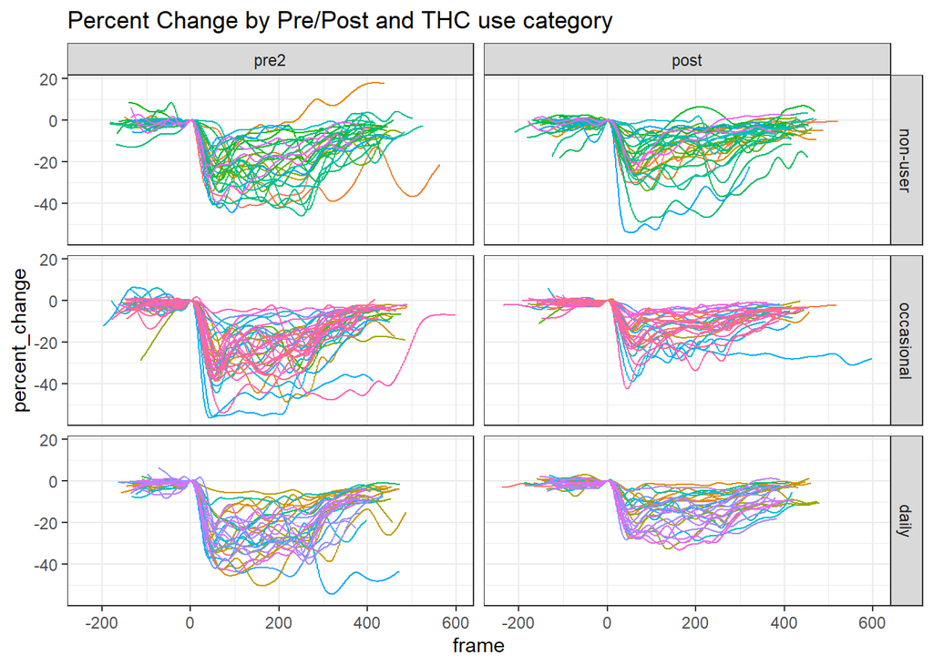

```r
ggplot(right.df, aes(x=frame, y = percent_change, group = subject_id, color = subject_id))+
  geom_line(show.legend = FALSE)+
  facet_grid(rows = vars(user_cat), cols = vars(tp))+
  labs(title = "Percent Change by Pre/Post and THC use category")+
  theme_bw()
```

Frame “NA”, pupil size and percent change are present

```r
View(ps[is.na(ps$frame), ])
```

Plots of Left and Right Eye for “POST” data. One pt has negative values for pupil size.

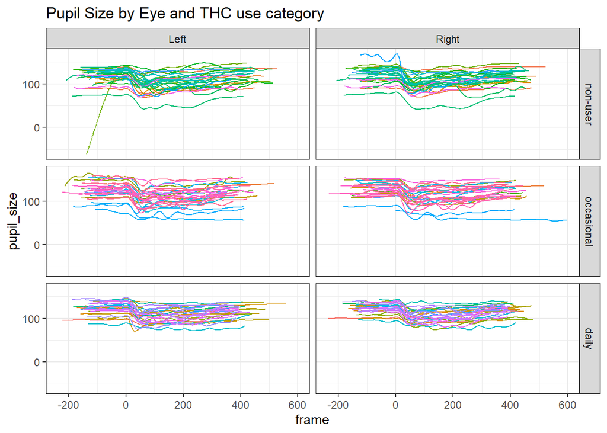

```r
post.df <- ps[ps$tp == "post", ]

ggplot(post.df, aes(x=frame, y = pupil_size, group = subject_id, color = subject_id))+
  geom_line(show.legend = FALSE)+
  facet_grid(rows = vars(user_cat), cols = vars(eye))+
  labs(title ="Pupil Size by Eye and THC use category")+
  theme_bw()
```

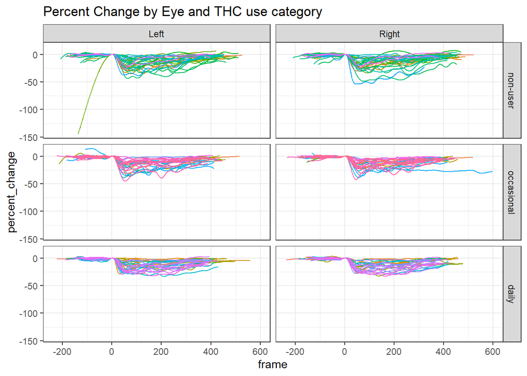

```r
ggplot(post.df, aes(x=frame, y = percent_change, group = subject_id, color = subject_id))+
  geom_line(show.legend = FALSE)+
  facet_grid(rows = vars(user_cat), cols = vars(eye))+
  labs(title = "Percent Change by Eye and THC use category")+
  theme_bw()
```

###Find potential mis-aligned data streams I’m looking for any sharp declines over 10 frames after the 150th frame and then visualizing those trajectories to determine if there might be misalignment of the light test start frame.

```r
ps$lagPctChg <- c(rep(0, 10), diff(ps$percent_change, lag = 10))
ps$lagID <- dplyr::lag(ps$subject_id, 10)
ps$lagtime <- dplyr::lag(ps$time, 10)
ps$lagEye <- dplyr::lag(ps$eye, 10)

ps$lagPctChg <- ifelse(ps$subject_id == ps$lagID & ps$time == ps$lagtime & ps$eye == ps$lagEye,
                       ps$lagPctChg, 0)

summary(ps$lagPctChg[ps$frame > 150])
```

```
##    Min. 1st Qu.  Median    Mean 3rd Qu.    Max.    NA's
## -9.8625 -0.1754  0.3748  0.4632  1.1062 10.4196     373
```

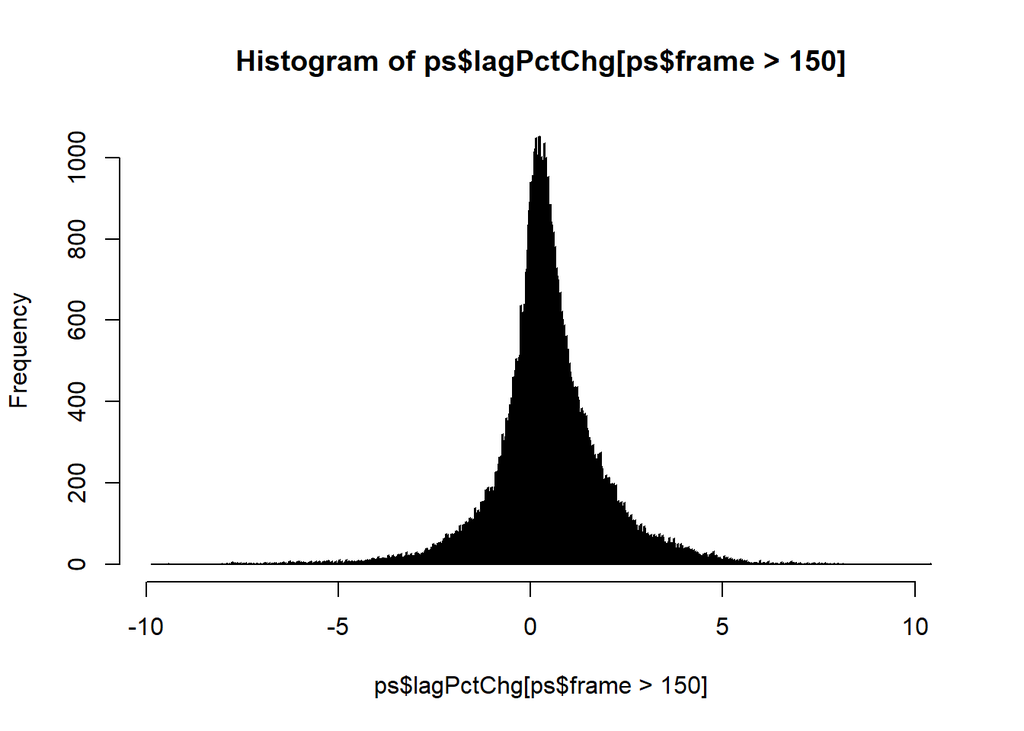

```r
hist(ps$lagPctChg[ps$frame > 150], breaks = 1000)
```

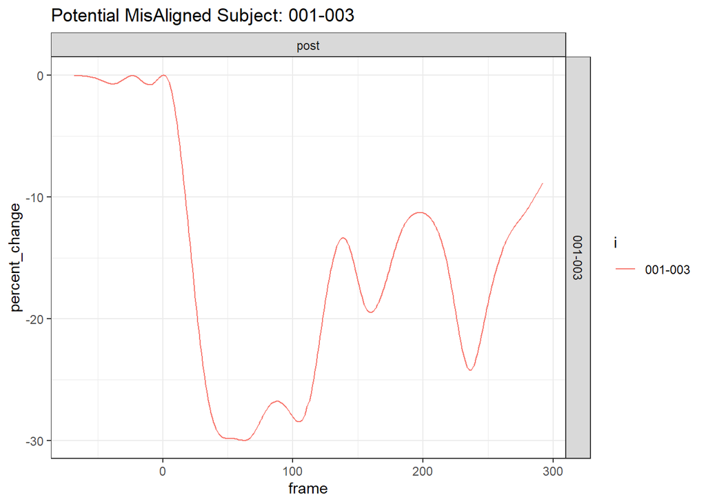

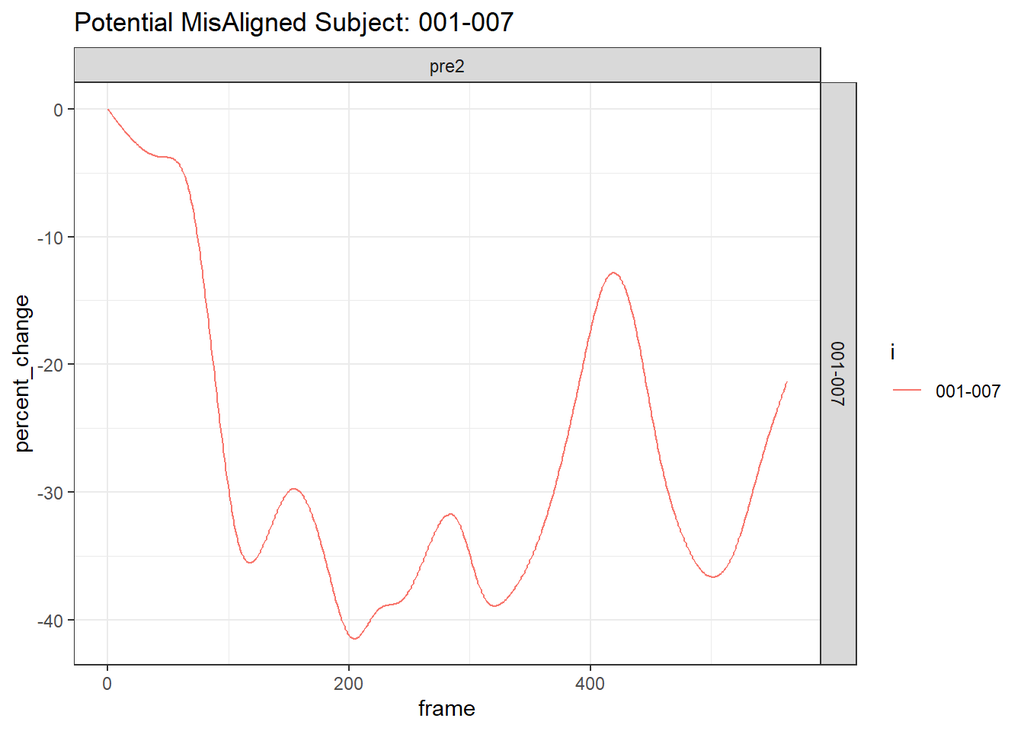

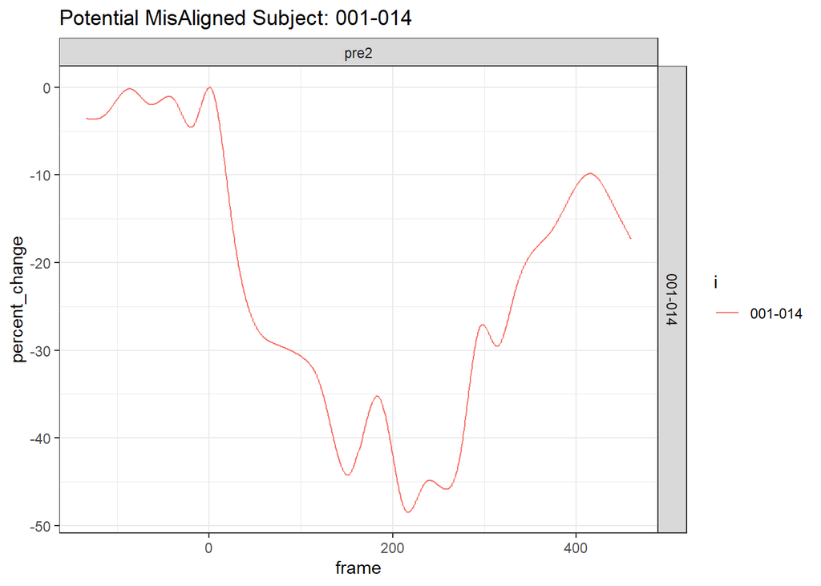

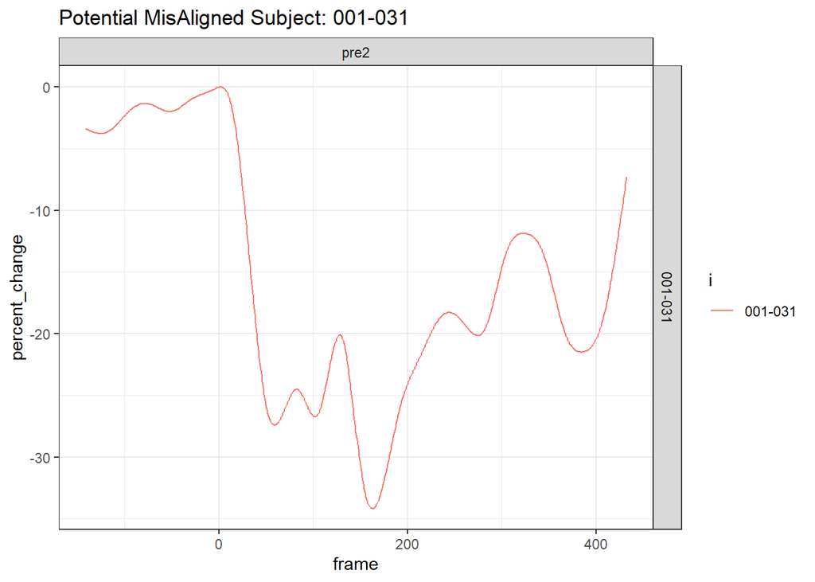

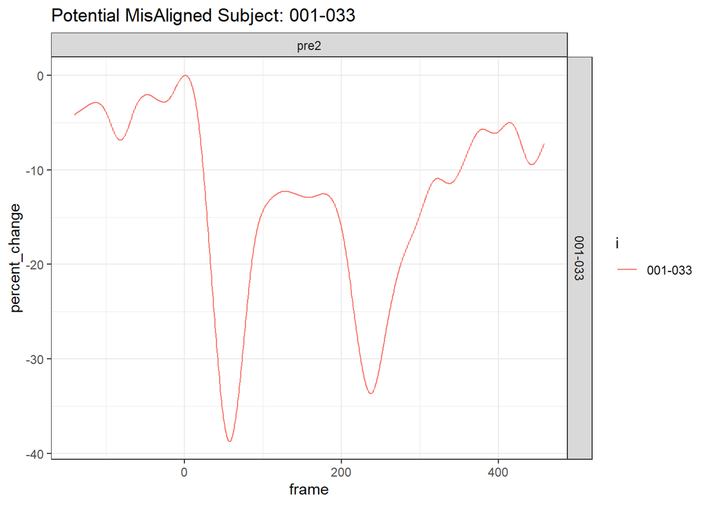

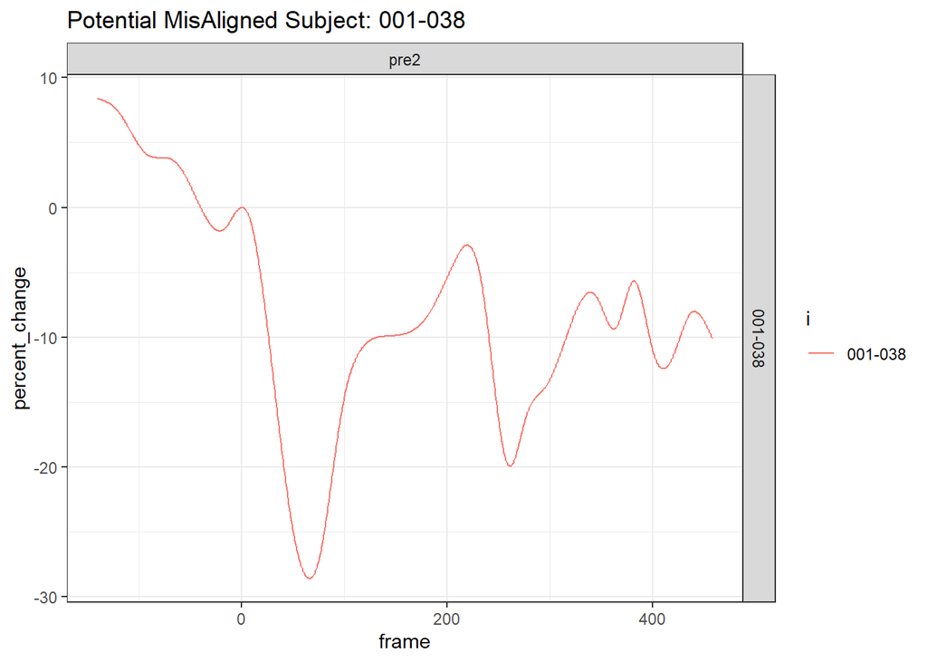

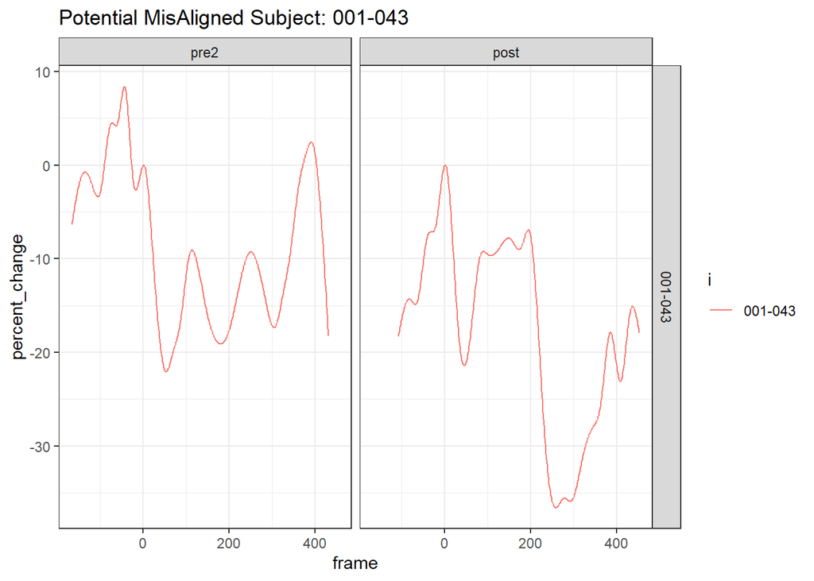

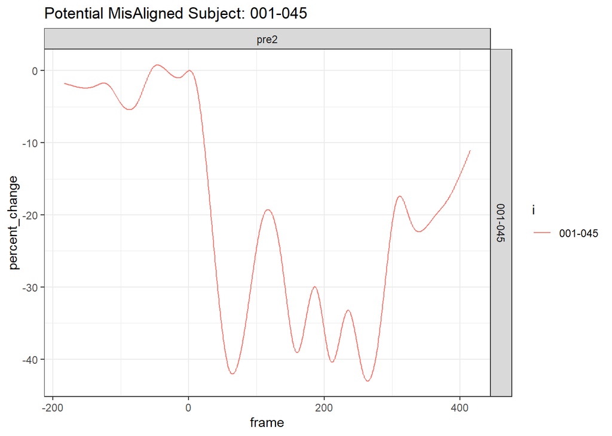

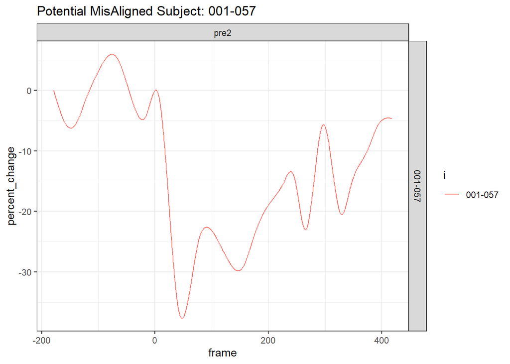

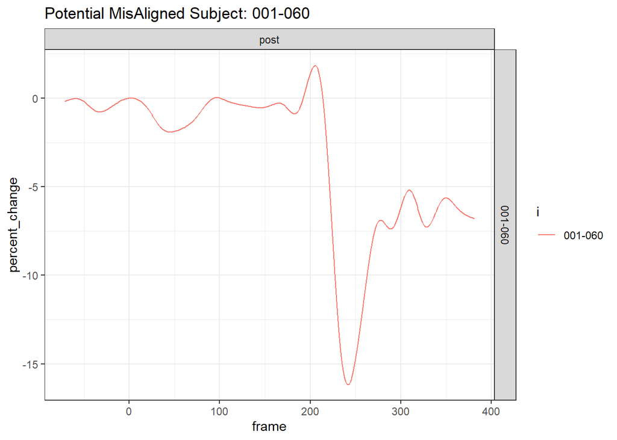

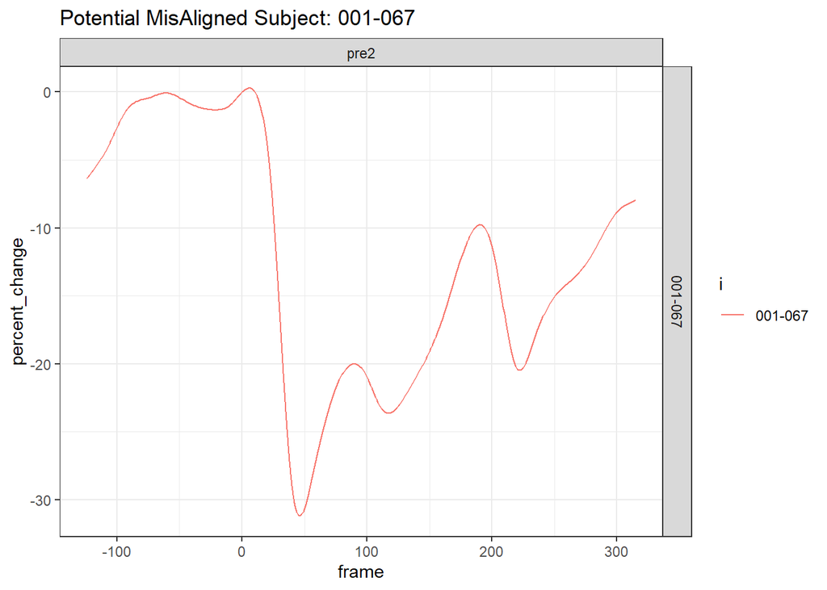

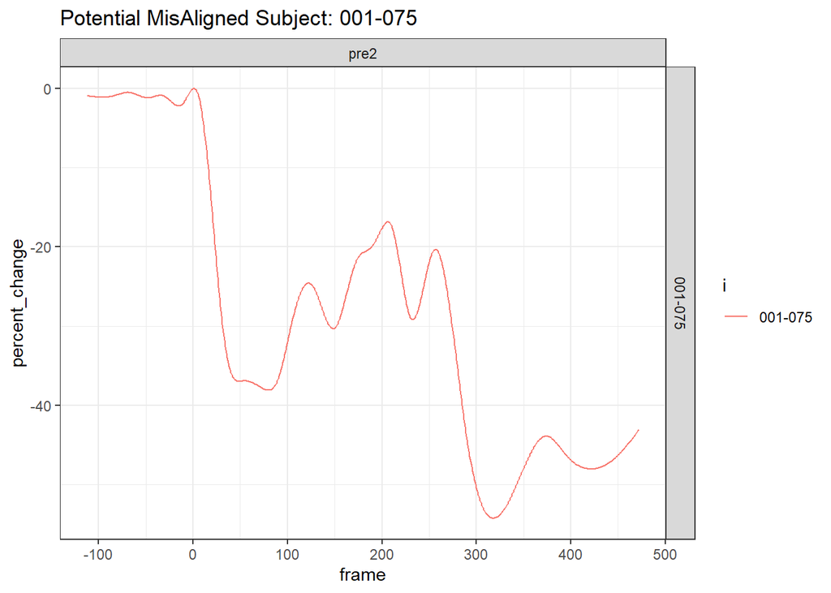

[3 more figures not shown]

```r
ps.150 <- ps[ps$frame > 150  & ps$eye == "Right", ]

pot.misaligned <- unique(ps.150[ps.150$lagPctChg <= -5,  c("subject_id", "time", "user_type", "eye")])
pot.misaligned <- pot.misaligned[!(is.na(pot.misaligned$subject_id)), ]
pot.misaligned$misaligned  <- 1

misaligned <- merge(ps, pot.misaligned,
                    by= c("subject_id", "time", "user_type", "eye"),
                    all.y = T)

mis.right <- misaligned[misaligned$eye == "Right", ]

misAlign.id <- unique(misaligned$subject_id)

for(i in misAlign.id){
  print(ggplot(mis.right[mis.right$subject_id == i, ],
                              aes(x=frame, y = percent_change,
                                  group = subject_id, color = i))+
                        geom_line()+
                        facet_grid(rows = vars(subject_id), cols = vars(tp))+
                        labs(title = paste0("Potential MisAligned Subject: ", i))+
                        theme_bw())
}
```

```r
# jpeg(file.path(ps_folder, "Potential_Misaligned_001_109.jpg"),
#      width = 12, height = 5, units = "in", res = 300)
# ggplot(mis.right[mis.right$subject_id == "001-109", ],
#        aes(x=frame, y = percent_change, group = subject_id, color = subject_id))+
#   geom_line()+
#   facet_grid(rows = vars(subject_id), cols = vars(tp))+
#   labs(title = "Potential MisAligned ")+
#   theme_bw()
# dev.off()

# jpeg(file.path(ps_folder, "Potential_Misaligned_001_060.jpg"),
#      width = 12, height = 5, units = "in", res = 300)
# ggplot(mis.right[mis.right$subject_id == "001-060", ],
#        aes(x=frame, y = percent_change, group = subject_id, color = subject_id))+
#   geom_line()+
#   facet_grid(rows = vars(subject_id), cols = vars(tp))+
#   labs(title = "Potential MisAligned ")+
#   theme_bw()
# dev.off()
```